# Binomial distributions

Michael Friendly

2022-12-13

Here are some simple examples of working with binomial distributions. The motivating example is `vcd::WeldonDice`, reporting the frequencies of obtaining a 5 or 6 in throws of 12 dice. If the dice were fair, this should give a binomial distribution, Bin(12, 1/3).

```r
library(vcd)
```

```r
library(lattice)
library(ggplot2)
data(WeldonDice, package = "vcd")
WeldonDice
```

```
## n56
##    0    1    2    3    4    5    6    7    8    9   10
##  185 1149 3265 5475 6114 5194 3067 1331  403  105   18
```

### plot Bin(12, 1/3), like Weldon’s dice

The `dbinom()` function calculates the probabilities in a binomial, Bin(n, p) for a range of `x` values.

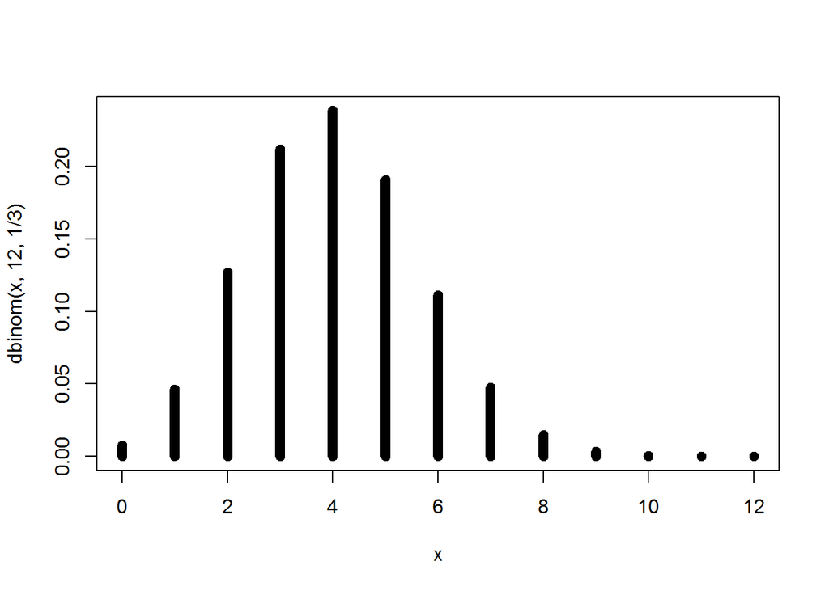

```r
x <- seq(0,12)
plot(
  x = x,
  y = dbinom(x, 12, 1 / 3),
  type = "h",
  lwd = 8
)
```

## Do the same, with better labels, and `lines()`

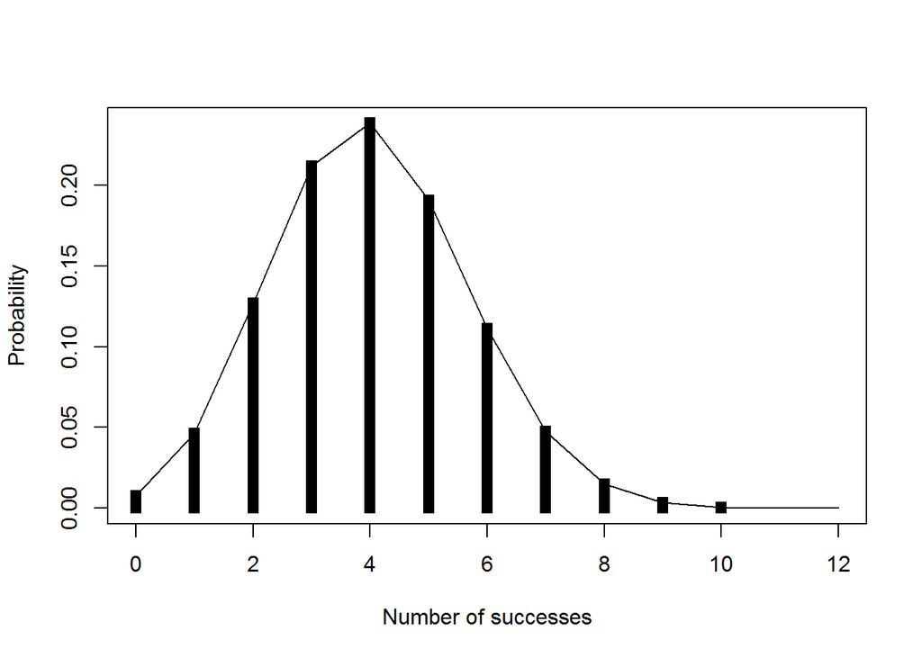

```r
x <- seq(0,12)
plot(
  x = x,
  y = dbinom(x, 12, 1 / 3),
  type = "h",
  xlab = "Number of successes",
  ylab = "Probability",
  lwd = 8,
  lend = "square"
)
lines(x=x, y=dbinom(x,12,1/3))
```

## Calculate expected frequencies & contributions to $\chi^2$

There’s a wrinkle here, in that the data reported in `WeldonDice` for `x=10` represents the frequency for 10 or more 5s or 6s.

```r
data(WeldonDice, package="vcd")
Weldon.df <- as.data.frame(WeldonDice)   # convert to data frame

x <- seq(0,12)
Prob <- dbinom(x, 12, 1/3)               # binomial probabilities
Prob <- c(Prob[1:10], sum(Prob[11:13]))  # sum values for 10+
Exp  <- round(sum(WeldonDice)*Prob)         # expected frequencies
Diff <- Weldon.df[,"Freq"] - Exp          # raw residuals
Chisq = Diff^2 /Exp
data.frame(Weldon.df, Prob=round(Prob,4), Exp, Diff, Chisq)
```

```
##    n56 Freq   Prob  Exp Diff     Chisq
## 1    0  185 0.0077  203  -18 1.5960591
## 2    1 1149 0.0462 1216  -67 3.6916118
## 3    2 3265 0.1272 3345  -80 1.9133034
## 4    3 5475 0.2120 5576 -101 1.8294476
## 5    4 6114 0.2384 6273 -159 4.0301291
## 6    5 5194 0.1908 5018  176 6.1729773
## 7    6 3067 0.1113 2927  140 6.6962761
## 8    7 1331 0.0477 1255   76 4.6023904
## 9    8  403 0.0149  392   11 0.3086735
## 10   9  105 0.0033   87   18 3.7241379
## 11  10   18 0.0005   14    4 1.1428571
```

## Use `vcd::goodfit()`

`vcd::goodfit()` calculates probabilities, fitted values and residuals for a given distribution type. The `plot()` method for a `goodfit` object gives a `rootogram()`.

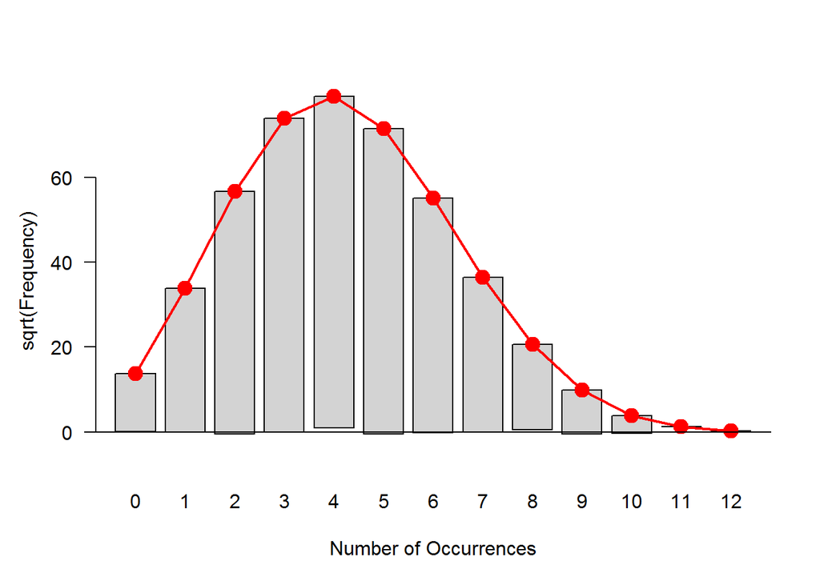

```r
goodfit(WeldonDice, type = "binomial", par = list(size=12)) |> plot()
```

## Plotting binomial distributions

### create a set of binomial distributions, Bin(12, p)

```r
# `dbinom()` can take vector inputs for the parameters

x <- seq(0,12)                # values of x
p <- c(1/6, 1/3, 1/2, 2/3)    # values of p
x <- rep(x, 4)                # replicate, length(p) times
p <- rep(p, each=13)          # replicate, each length(x)
bin.df <- data.frame(x, prob = dbinom(x, 12, p), p)
bin.df$p <- factor(bin.df$p, labels=c("1/6", "1/3", "1/2", "2/3"))
str(bin.df)
```

```
## 'data.frame':    52 obs. of  3 variables:
##  $ x   : int  0 1 2 3 4 5 6 7 8 9 ...
##  $ prob: num  0.1122 0.2692 0.2961 0.1974 0.0888 ...
##  $ p   : Factor w/ 4 levels "1/6","1/3","1/2",..: 1 1 1 1 1 1 1 1 1 1 ...
```

## Better version: using `expand.grid()`

```r
XP <-expand.grid(x=0:12, p=c(1/6, 1/3, 1/2, 2/3))
bin.df <- data.frame(XP, prob=dbinom(XP[,"x"], 12, XP[,"p"]))
bin.df$p <- factor(bin.df$p, labels=c("1/6", "1/3", "1/2", "2/3"))
str(bin.df)
```

```
## 'data.frame':    52 obs. of  3 variables:
##  $ x   : int  0 1 2 3 4 5 6 7 8 9 ...
##  $ p   : Factor w/ 4 levels "1/6","1/3","1/2",..: 1 1 1 1 1 1 1 1 1 1 ...
##  $ prob: num  0.1122 0.2692 0.2961 0.1974 0.0888 ...
```

### Using `lattice::xyplot()` to plot the distributions

With lattice, the `groups = p` argument gives a separate line for each level of `p`. `pch` and `col` arguments set the point symbols and colors. The `key` argument is used to define the legend for the plot.

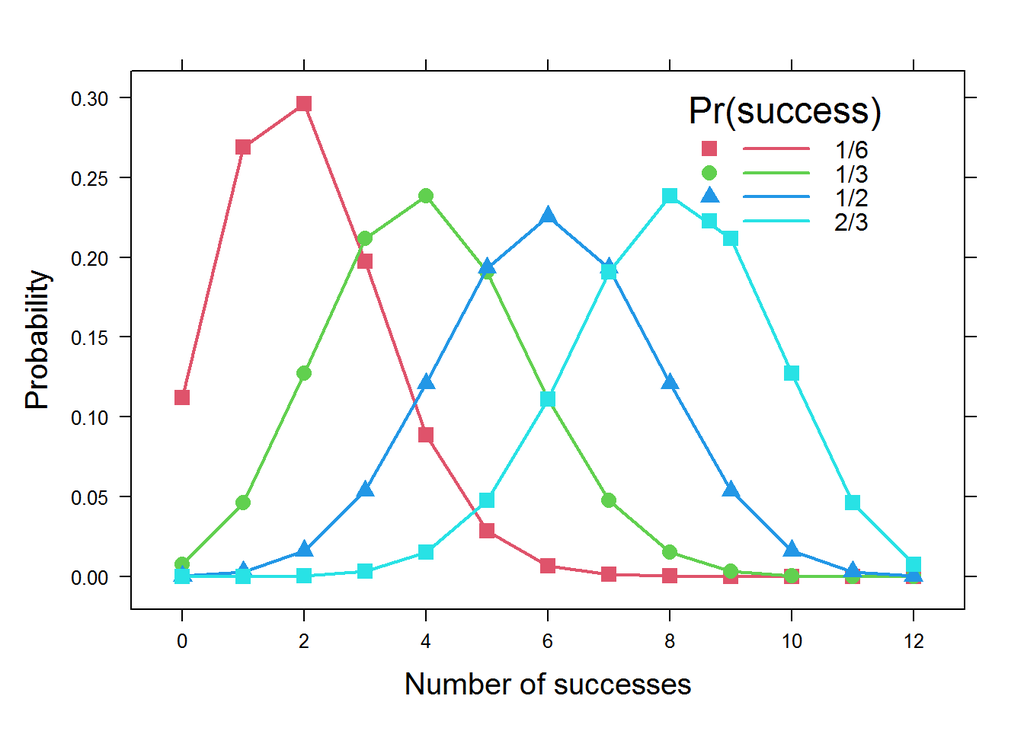

```r
library(lattice)

mycol <- palette()[2:5]
xyplot( prob ~ x, data=bin.df, groups=p,
    xlab=list('Number of successes', cex=1.25),
    ylab=list('Probability',  cex=1.25),
    type='b', pch=15:17, lwd=2, cex=1.25, col=mycol,
    key = list(
                    title = 'Pr(success)',
                    points = list(pch=15:17, col=mycol, cex=1.25),
                    lines = list(lwd=2, col=mycol),
                    text = list(levels(bin.df$p)),
                    x=0.9, y=0.98, corner=c(x=1, y=1)
                    )
    )
```

## The same, using `ggplot2`

For this plot, to give separate curves for each level of `p`, I assign this to both the `color` & `shape` aesthetics.

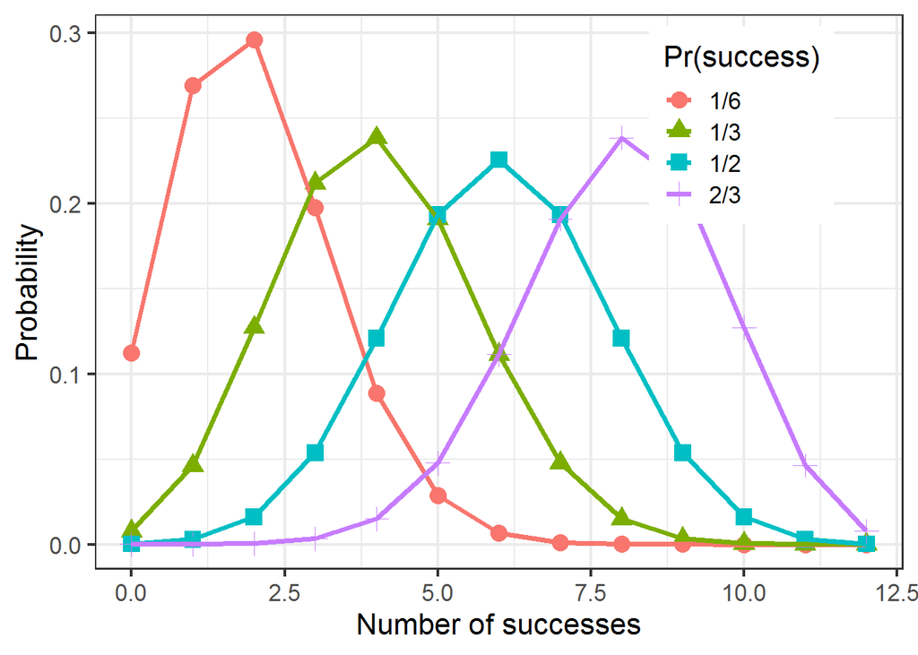

```r
library(ggplot2)
ggplot(bin.df, aes(x = x, y = prob, color = p, shape = p)) +
  geom_point(size=4) +
  geom_line(linewidth = 1.25) +
  labs(x = "Number of successes",
       y = "Probability") +
  scale_colour_discrete("Pr(success)") +
  scale_shape_discrete("Pr(success)") +
  theme_bw(base_size = 16) +
  theme(legend.position = c(0.8, 0.8))
```